# VIEWpoly: a visualization tool to integrate and explore results of polyploid genetic analysis

Cristiane Taniguti, Gabriel Gesteira, Jeekin Lau, Guilherme Pereira, David Byrne, Zhao-Bang Zeng, Oscar Riera-Lizarazu and Marcelo Mollinari

2021-12-10

# Introduction

`VIEWpoly` is a shiny app and R package for visualizing and exploring results from [polyploid computational tools](https://www.polyploids.org/) using an interactive graphical user interface. The package allows users to directly upload output files from [polymapR](https://cran.r-project.org/web/packages/polymapR/index.html) (Bourke et al. (2018)), [MAPpoly](https://cran.r-project.org/web/packages/mappoly/index.html) (Mollinari et al. (2019)), [polyqtlR](https://cran.r-project.org/web/packages/polyqtlR/index.html) (Bourke et al. (2021)), [QTLpoly](https://cran.r-project.org/web/packages/qtlpoly/index.html) (Pereira et al. (2019)), diaQTL (Amadeu et al. (2021)) and genomic assembly, variants, annotation and alignment files. VIEWpoly uses [shiny](https://cran.r-project.org/web/packages/shiny/index.html), [golem](https://cran.r-project.org/web/packages/golem/index.html), [ggplot2](https://cran.r-project.org/web/packages/ggplot2/index.html), [plotly](https://cran.r-project.org/web/packages/plotly/index.html), and [JBrowseR](https://cran.r-project.org/web/packages/JBrowseR/index.html) libraries to graphically display the QTL profiles, positions, alleles estimated effects, progeny individuals containing specific haplotypes and their breeding values. It is also possible to access marker dosage and parental phase from the linkage map. If genomic information is available, the corresponding QTL positions are interactively explored using JBrowseR interface, allowing the search for candidate genes. It also provides features to download specific information into comprehensive tables and images for further analysis and presentation.

Check also our [tutorial video](https://www.youtube.com/watch?v=yqWX86uT5jM).

The app is organized into four modules: `Input data`, `VIEWqtl`, `VIEWgenome`, and `VIEWmap`.

# Install and run the app

Use the following code to install and run the app.

```r
devtools::install_github("mmollina/viewpoly")
viewpoly::run_app()
```

Each one of the modules here described can be accessed clicking in the top menu:

[figure not shown]

# Input data

Use this module to select an example dataset or to upload your files.

For uploading your dataset:

The app will convert the uploaded files from `Upload linkage map` and `Upload QTL analysis` sessions into the VIEWpoly file format. You can download it using the `Download VIEWpoly dataset` session. Therefore, in future access to this app, you need to upload just a single file to access the QTL and Map modules app features for this dataset. VIEWpoly files can be uploaded in the `Upload VIEWpoly dataset`. You can also just load the VIEWpoly object in your R environment (code: `load("my_dataset.RData")`) that VIEWpoly will identify and list it in the `Upload VIEWpoly dataset` session. The VIEWpoly object does not store genome information, these files will need to be uploaded again.

### Available example datasets

The linkage map, QTL analysis results from previous studies on a tetraploid potato mapping population are available together with the package:

- [Tetraploid potato - Atlantic x B1829-5](https://www.nature.com/articles/s41437-021-00416-x)

To save space in the package repository, it contains the entire linkage map and QTL analysis but just a subset of individuals and the genome information (FASTA and GFF3).

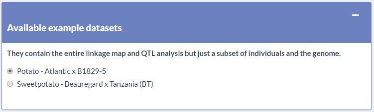

You can access other example files here, which includes also data from a hexaploid sweetpotato mapping population:

- [Hexaploid sweet potato - Beauregard x Tanzania](https://academic.oup.com/genetics/article/215/3/579/5930535)

You can select one of them to explore the software features before uploading your data. By default, the app will display the tetraploid potato dataset.

### Upload linkage map files

Click in the `+` on the right side of the `Upload linkage map files` box to open the options for uploading the linkage map information.

[figure not shown]

You can choose to upload files for one of the three options: `MAPpoly`, `polymapR`, or standard formats.

#### Upload MAPpoly or polymapR output

Click in one the the `+` inside the box to open the description for the select option.

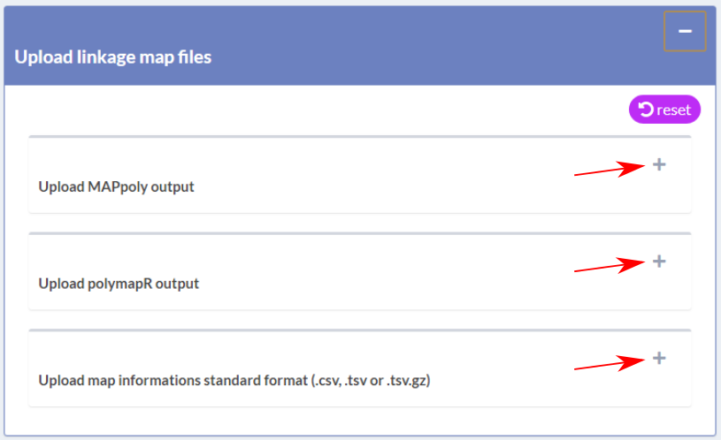

Once you open one of them, you can see instructions about how should be the files uploaded into this spot. In the example below, it is expected an RData file containing an R object of class `mappoly.map`. The provided link points to the MAPpoly tutorial, where you can find further information about all the procedures to build a linkage map and to obtain this specific object.

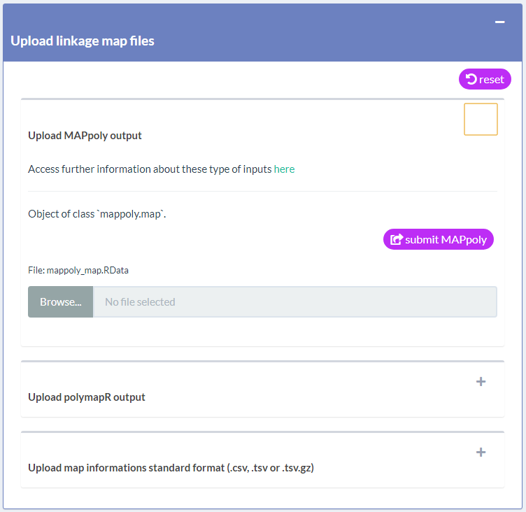

Click in `Browse...` to search for the file on your computer and load it into the app.

[figure not shown]

Wait for the upload be complete and click in the submit button (in this case:`submit MAPpoly`):

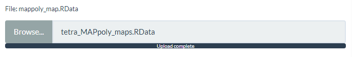

After clicking submit, if you want to change any of the uploaded files, you must click on the `reset` button before upload new files.

#### Upload linkage map files with stardard format (.csv, .tsv or tsv.gz)

If you choose to submit the linkage map files in standard formats you can download example files to set the right formats with your data:

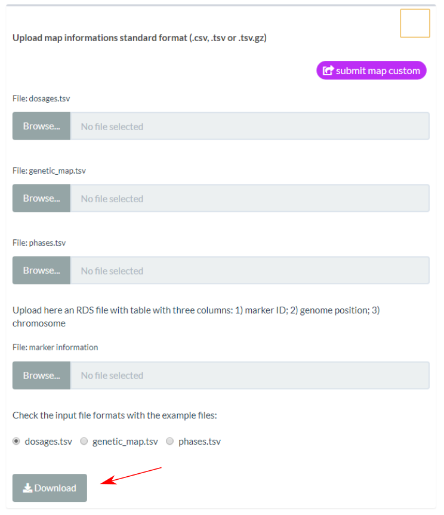

Select which of the example files you want to download: `dosages.tsv`, `genetic_map.tsv`, `phases.tsv`, and click in `Download`.

### Upload QTL analysis files

Upload files for one of the four options: `QTLpoly`, `diaQTL`, `polyqtlR`, or standard formats.

Pick one of the options and click on the `+` on the right side of the box to open the description of the required files.

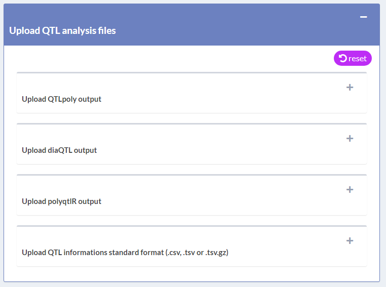

#### Upload QTLpoly, diaQTL or polyqtlR output

From the QTL analysis, at least four files are required. The example code shows the functions the required object comes from. After loading all required files, click on `submit` button:

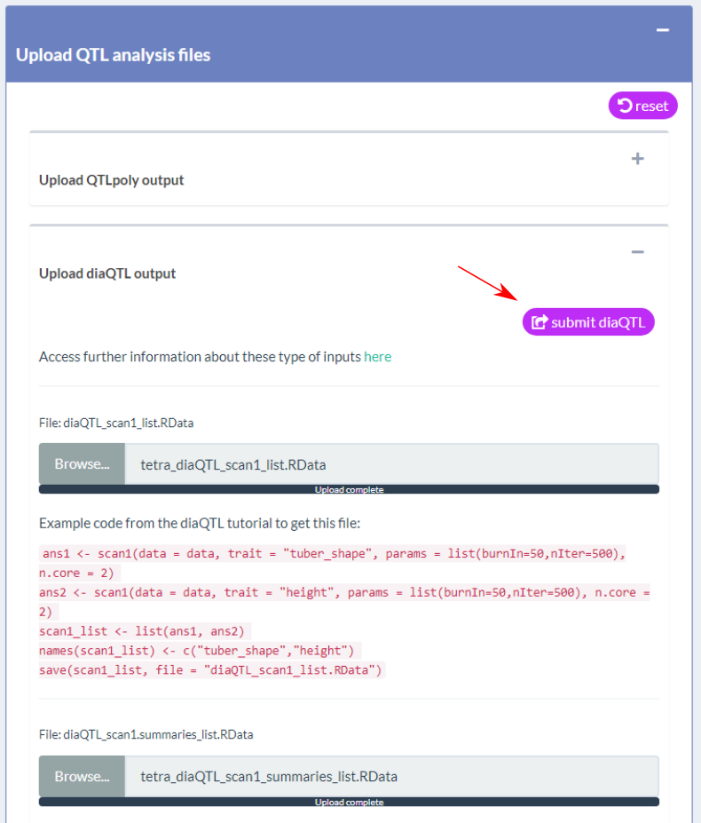

#### Upload QTL analysis results with standard format (.csv, .tsv or .tsv.gz)

If you choose to submit the QTL analysis files with standard formats you can download example files to set the right formats with your data:

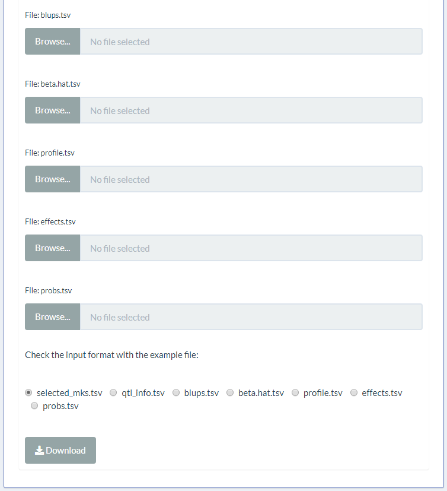

### Upload Genome Browser files

Uploading files in this session will open access to the `Genome` tab features. The files are included as tracks into the [JBrowseR](https://gmod.github.io/JBrowseR/) tool. Only the assembly (FASTA) file is required to access the feature, the others are optional.

- Assembly

You can compress the FASTA file using [bgzip](http://www.htslib.org/doc/bgzip.html) with:

```bash
bgzip NSP306_trifida_chr_v3.fa
```

You must submit also the indexes files generated by [samtools](https://samtools.github.io/).

```bash
samtools faidx NSP306_trifida_chr_v3.fa.gz
```

After this, you can submit the three files at once in the app:

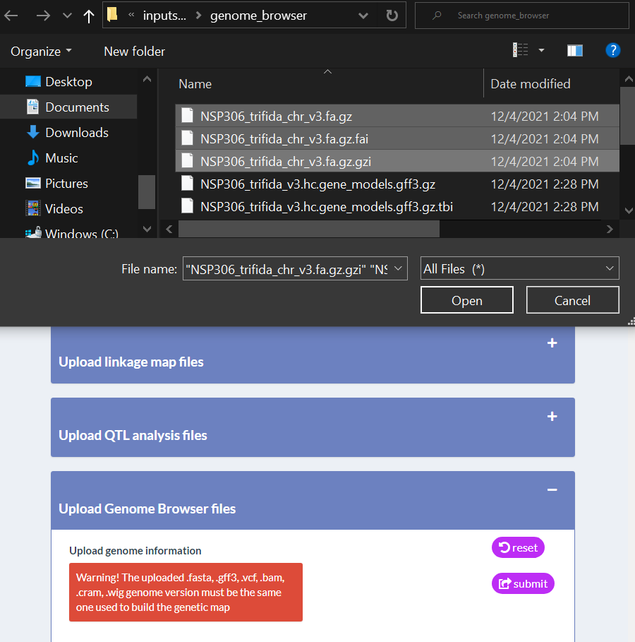

- Annotation

You may need to sort your annotation file before uploading it. One way of doing it is using gff3sort tool:

```bash
gff3sort.pl --precise --chr_order natural NSP306_trifida_v3.hc.gene_models.gff3 | bgzip > NSP306_trifida_v3.hc.gene_models.sorted.gff3.gz
```

And generated the indexes with [tabix](http://www.htslib.org/doc/tabix.html):

[figure not shown]

```bash
tabix -p gff NSP306_trifida_v3.hc.gene_models.sorted.gff3.gz
```

- Variants

The VCF file should also be tabixed:

```bash
tabix -p variants.vcf
```

- Alignment

Alignment files BAM should be together with BAI or CSI files, and for CRAM files only CRAI is allowed.

For creating BAI index:

```bash
samtools index *.bam
```

- bigWig

No index files are required.

Check further information in [JBrowse documentation](https://jbrowse.org/jb2/docs/user_guide/).

### Download VIEWpoly dataset

Once you submitted the linkage map and QTL analysis results, VIEWpoly converts all files to a single R object of class `viewpoly`. It keeps only the information required for building the app graphics for QTL and linkage map analysis. You can set the name of the dataset R object using the box. Avoid using special characters or spaces. Click in `Download` to save as an RData object.

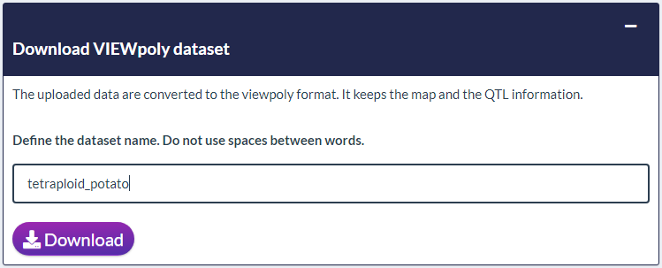

### Upload VIEWpoly dataset

Once you have a viewpoly object file, you can access VIEWpoly features for this dataset just submitting this single file in the `Upload VIEWpoly dataset` session:

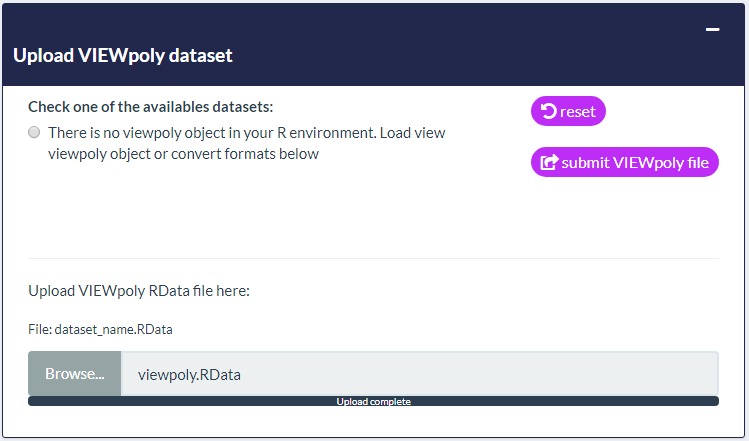

You can also load your VIEWpoly dataset in your R environment and it will be listed in this session.

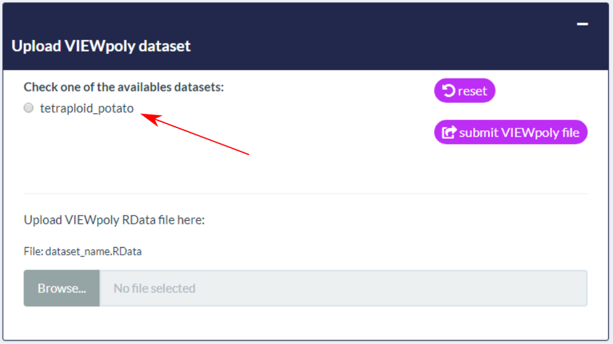

```r
load("viewpoly.RData")
viewpoly::run_app()
```

If you have more than one VIEWpoly dataset available in your R environment, all them will be listed:

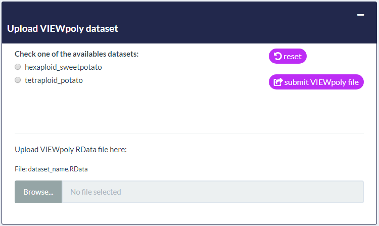

Don’t forget to press `submit` after uploading the file or choose the listed dataset. After, you can go back to `Upload Genome Browser files` to upload the genome information for this selected dataset.

# VIEWqtl: the QTL Browser

If you uploaded the QTL analysis information for any of the software options, you can access the features in the `QTL` tab. If you didn’t upload anything, the tetraploid potato analysis example will be displayed.

### Select linkage groups and phenotypes

You can explore any of the linkage groups or the phenotypes together or separated. Select them using the two upper boxes:

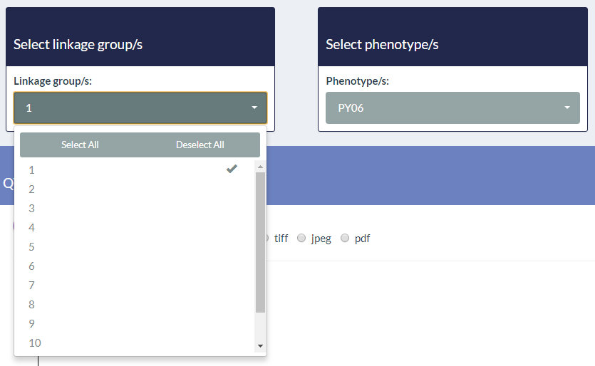

### QTL profile

Once you selected the group and phenotypes, the QTL profile curve will be plotted. It shows a measure of statistical significance (that can be different according to software used)(y-axis) of the trait (colors) for each map position (x-axis). The triangles in the bottom part point to the peak of the significance and QTL position. The black line crossing the triangle defines the QTL confidence interval.

If you uploaded data from **QTLpoly** you will see a graphic like this:

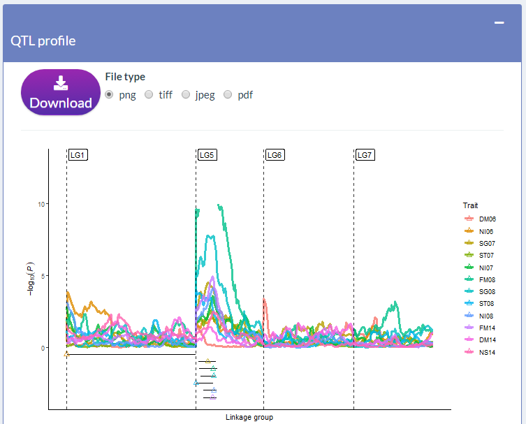

If you uploaded data from **diaQTL** you will see a graphic like this:

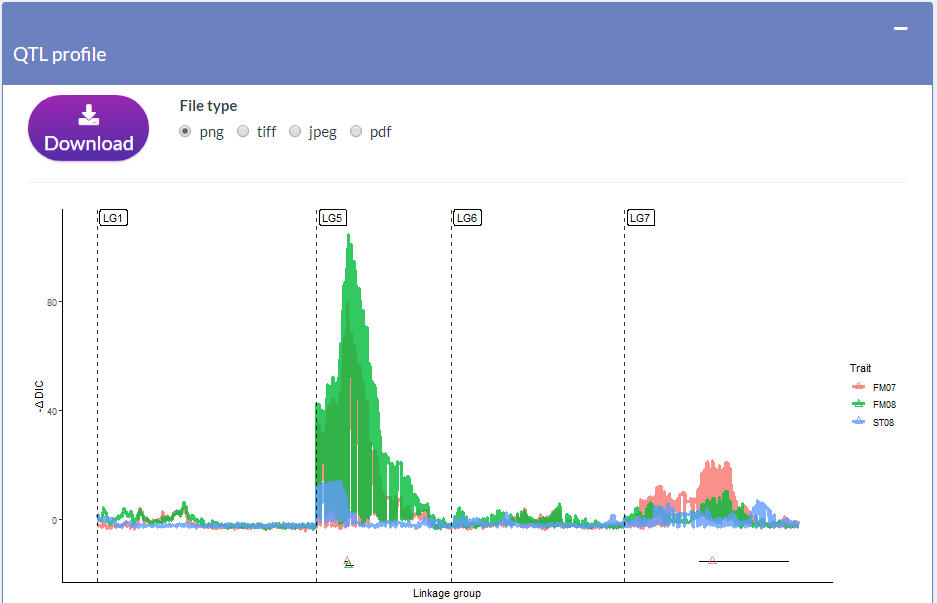

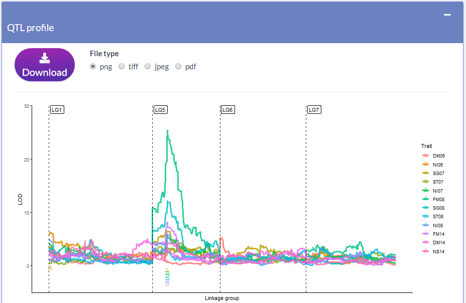

You can download this figure and all other figures from VIEWpoly selecting the format in the `file type` field and pressing the `Download` button just on top of each figure.

For further information about this graphics, please check Pereira et al. (2019), Amadeu et al. (2021) and Bourke et al. (2021) tutorials.

#### Effects

You can drag your mouse cursor to select the triangles at the bottom of the graphic to explore particular QTL effects progeny haplotypes, breeding values and to get the QTL summary table in the next sessions:

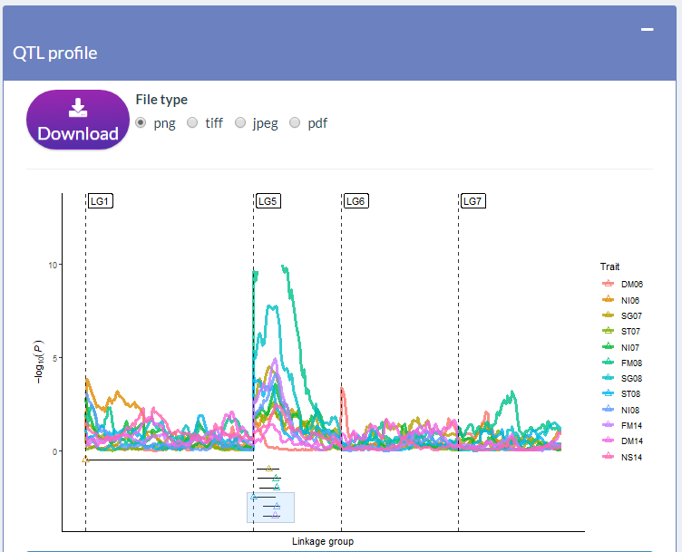

**WARNING**: If you want to change the linkage group or phenotype evaluated first deselect the triangles (single click any other location of the graphic). **Not doing this will crash the app**.

Click in the `+` in the right corner of the `Effects` session to see the graphics. By default, VIEWpoly displays the `bar` design:

- Additive (bar)

If you uploaded QTL data from **QTLpoly**, you will see something like this:

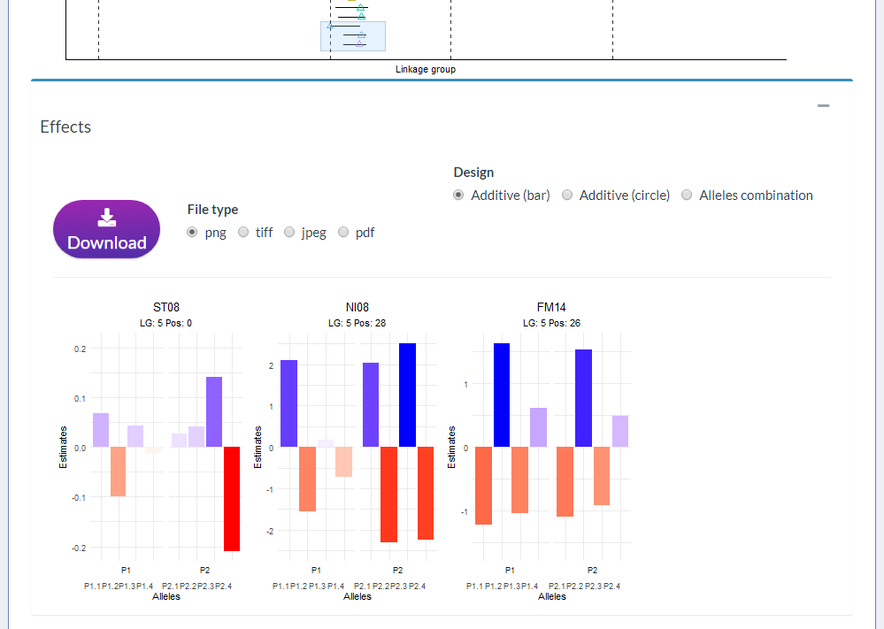

It displays the additive effect for each of the parent’s alleles on the selected QTL positions. Colors emphasize the intensity of the effects.

If you uploaded QTL data from **diaQTL**, you will see something like this:

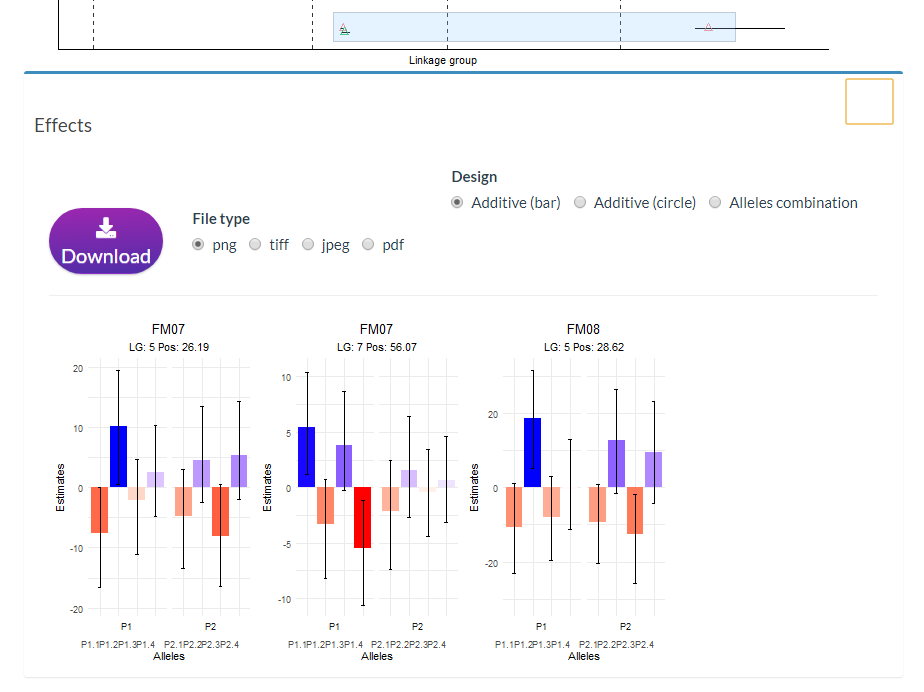

Similarly with QTLpoly, but includes a bayesian confidence interval for the effects.

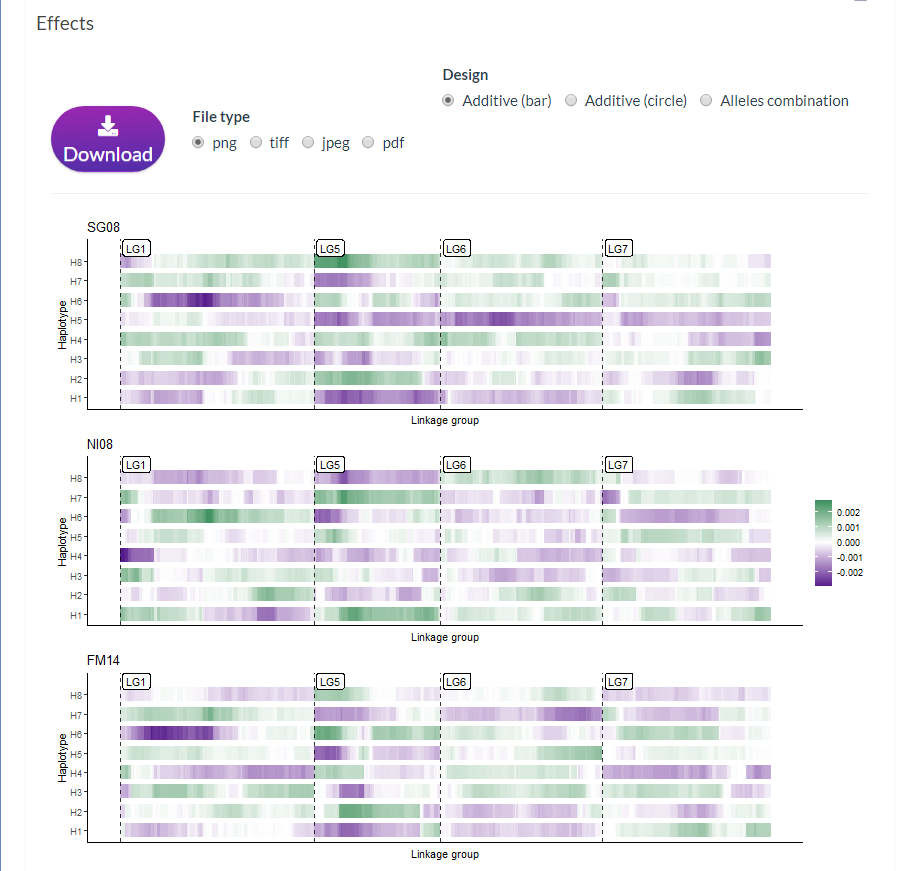

It plots the intensity of the effects across the entire linkage group for the selected QTL phenotype.

- Additive (circle)

Changing the `Design` to `Additive (circle)` the intensity of the effects is plotted in a circle graphic. The selected QTL from the same linkage group are plotted together in the same graphic. To be possible to compare the effects across different QTL and phenotypes, the values are standardized to be between -1 (center or circle) and 1. The dots colors are more intense close to the extreme values (-1 and 1) and their transparency increase when they are close to 0.

This design is only available for **QTLpoly** and **diaQTL** software results.

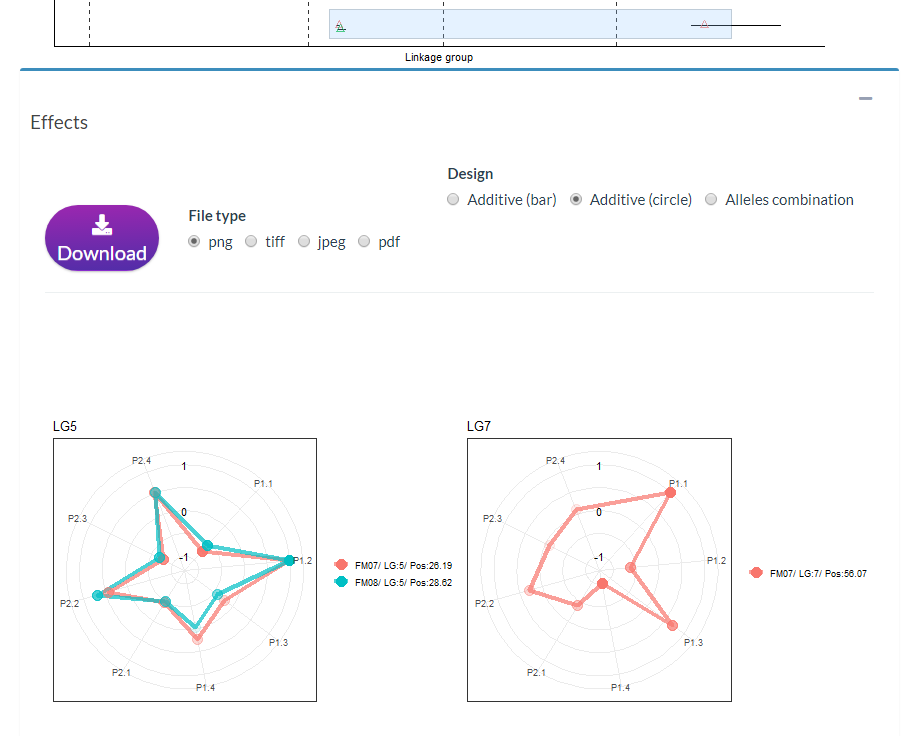

- Alleles combination

Changing the `Design` to `Alleles combination` a heatmap is plotted with the combined alleles (parents alleles x-axis x parents alleles y-axis) sum of additive and digenic effects in the upper diagonal and just the additive in the bottom diagonal.

This design is only available for **QTLpoly** and **diaQTL** software results.

If you uploaded QTL data from **QTLpoly**, you will see something like this:

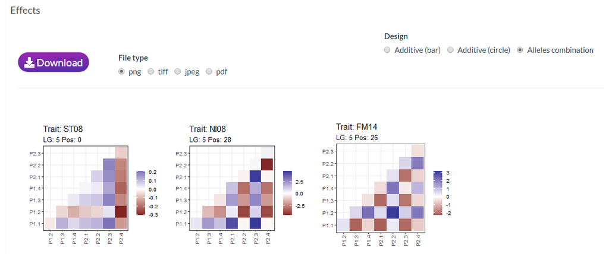

**QTLpoly** only considers additive effects.

If you uploaded QTL data from **diaQTL**, you will see something like this:

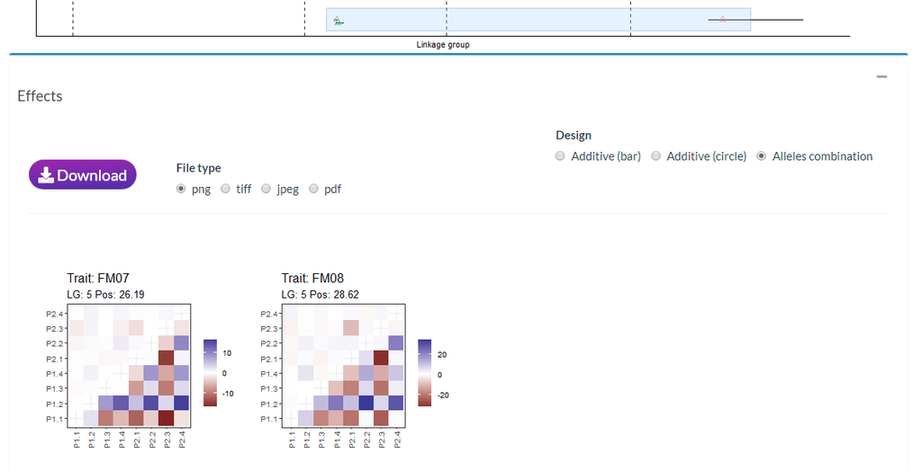

For further information about this graphics, please check Pereira et al. (2019), Amadeu et al. (2021) and Bourke et al. (2021).

#### Progenies haplotypes

To access this feature, first set the `Design` to `Additive (bar)`. By now, it is only implemented for results coming from **QTLpoly**.

Click on `update available haplotypes` button and after in the right corner of the `Select haplotypes` gray box, a window will open presenting all possible parents alleles for the QTL selected in the QTL profile graphic. You can select any combination of alleles and, after clicking on `submit selected haplotypes`, VIEWpoly will search the individuals in the progeny that have a probability higher than 0.5 of having all the alleles selected.

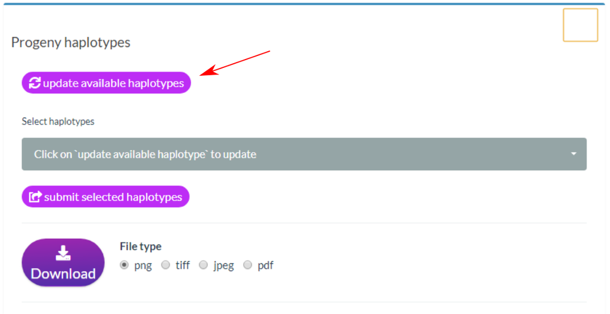

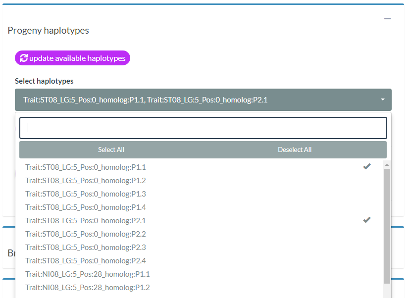

VIEWpoly displays the genotype probability profile for each individual identified with the selected alleles. The QTL position are pointed by dashed vertical lines. If only one linkage group is selected, the graphic will split vertically the probabilities for each possible homolog:

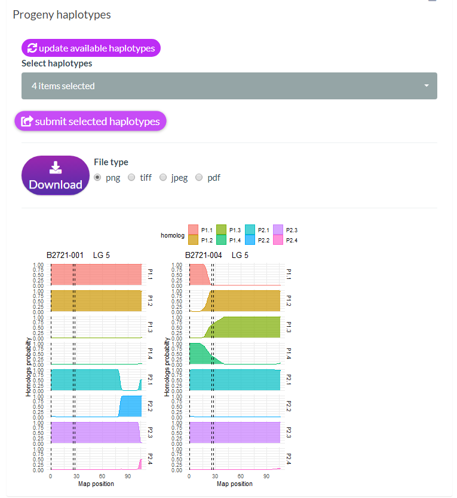

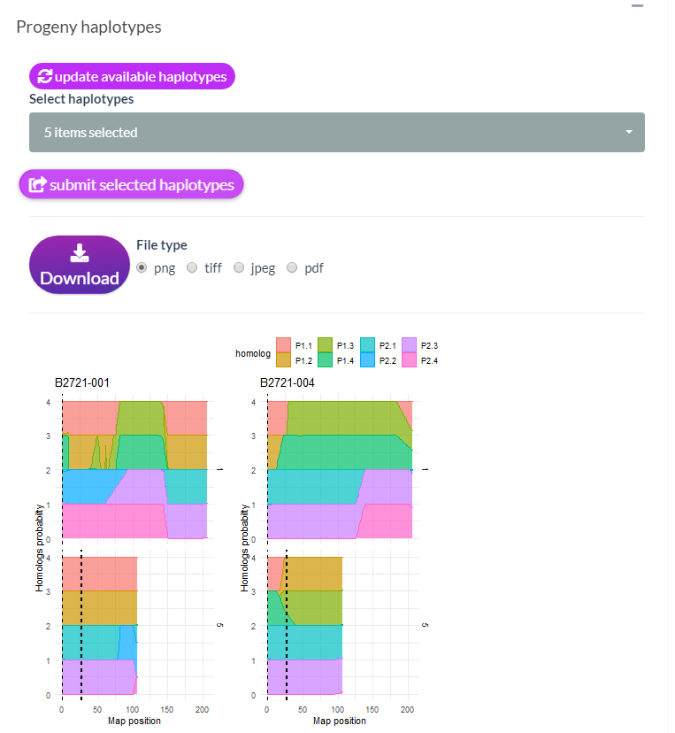

Because two groups must be represented in this case, the graphic design change to a stacked version.